# RBIF111 Homework 1

Shannon Joe

2026-11-04

# Question 1

## 1.1 A loop-based mean function

```r
my_mean <- function(x, na.rm = FALSE) {
  if (na.rm == TRUE) {
    x <- x[!is.na(x)]
  }
  total <- 0
  for (i in 1:length(x)) {
    total <- total + x[i]
  }
  total / length(x)
}
```

**How the code works:**

The function starts a running total at 0. The for loop visits each position in the vector and adds the value x[i] to the total. At the end it divides the total by length(x), the number of values.

```r
v <- c(4, 8, 15, 16, 23, 42)
my_mean(v)
```

```
## [1] 18
```

```r
mean(v)
```

```
## [1] 18
```

**Interpretation:** Both `my_mean(v)` and `mean(v)` returned 18, so my loop-based function gives the same answer as R’s built-in `mean()`.

## 1.2 Handling NA values

```r
v_na <- c(4, NA, 15, 16, NA, 42)

my_mean(v_na)
```

```
## [1] NA
```

```r
mean(v_na)
```

```
## [1] NA
```

```r
my_mean(v_na, na.rm = TRUE)
```

```
## [1] 19.25
```

```r
mean(v_na, na.rm = TRUE)
```

```
## [1] 19.25
```

**How the NA handling works:**

When `na.rm = TRUE`, the line `x <- x[!is.na(x)]` removes the missing values (the NAs) before the loop runs, so the mean is calculated from only the remaining numbers. In my example, `c(4, NA, 15, 16, NA, 42)` becomes `c(4, 15, 16, 42)`, which has 4 values. When `na.rm = FALSE`, the NAs stay in the vector, so the loop adds an NA into the total. In R, any number plus NA is NA, so the function returns `NA`. This matches how R’s `mean()` works, because the true mean cannot be known if some values are missing.

**Why the loop-based function and mean() are expected to agree:**

My function and `mean()` are expected to agree because they use the same definition of a mean: add up all the values and divide by the number of values. My function just does the adding one value at a time with a loop. Because the math is the same, both give the same answer, as shown above.

## 1.3 Mean of a clinical variable from the DuckDB repository

Confirm the table and column exist and are numeric:

```r
tabs <- DBI::dbListTables(con)
grep("BMX", tabs, value = TRUE)
```

```
## [1] "NHANES_BMX"
```

```r
# Replace NHANES_BMX with the exact table name printed above
DBI::dbGetQuery(con, "DESCRIBE NHANES_BMX")
```

```
##     column_name column_type null  key default extra
## 1          SEQN      DOUBLE  YES <NA>    <NA>  <NA>
## 2      BMAEXLEN      DOUBLE  YES <NA>    <NA>  <NA>
## 3      BMAEXSTS      DOUBLE  YES <NA>    <NA>  <NA>
## 4      BMAEXCMT      DOUBLE  YES <NA>    <NA>  <NA>
## 5         BMXWT      DOUBLE  YES <NA>    <NA>  <NA>
## 6         BMIWT      DOUBLE  YES <NA>    <NA>  <NA>
## 7      BMXRECUM      DOUBLE  YES <NA>    <NA>  <NA>
## 8      BMIRECUM      DOUBLE  YES <NA>    <NA>  <NA>
## 9       BMXHEAD      DOUBLE  YES <NA>    <NA>  <NA>
## 10      BMIHEAD      DOUBLE  YES <NA>    <NA>  <NA>
## 11        BMXHT      DOUBLE  YES <NA>    <NA>  <NA>
## 12        BMIHT      DOUBLE  YES <NA>    <NA>  <NA>
## 13       BMXBMI      DOUBLE  YES <NA>    <NA>  <NA>
## 14       BMXLEG      DOUBLE  YES <NA>    <NA>  <NA>
```

[output cut: 41 more lines]

Pull the column with SQL and compare:

```r
bmi <- DBI::dbGetQuery(con, "SELECT BMXBMI FROM NHANES_BMX")$BMXBMI
length(bmi)
```

```
## [1] 119926
```

```r
sum(is.na(bmi))
```

```
## [1] 10519
```

```r
my_mean(bmi, na.rm = TRUE)
```

```
## [1] 25.76956
```

```r
mean(bmi, na.rm = TRUE)
```

```
## [1] 25.76956
```

```r
all.equal(my_mean(bmi, na.rm = TRUE), mean(bmi, na.rm = TRUE))
```

```
## [1] TRUE
```

**Interpretation:**

The `DESCRIBE` output shows that BMXBMI is a DOUBLE column, so it is numeric and safe to average. The column has 119926 values, and 10519 of them are NA, so I used `na.rm = TRUE`. My loop-based function gave a mean BMI of 25.77, which is the same as R’s `mean()`.

## 1.4 Hypothesis test: height vs weight

**Null hypothesis (H0):** There is zero correlation between height and weight in NHANES participants (the true correlation coefficient, r, equals 0).

**Alternative hypothesis (H1):** There is a correlation between height and weight in NHANES participants (the true correlation coefficient, r, is not equal to 0).

```r
hw <- DBI::dbGetQuery(con, "
  SELECT BMXHT, BMXWT
  FROM NHANES_BMX
  WHERE BMXHT IS NOT NULL AND BMXWT IS NOT NULL")
nrow(hw)
```

```
## [1] 109407
```

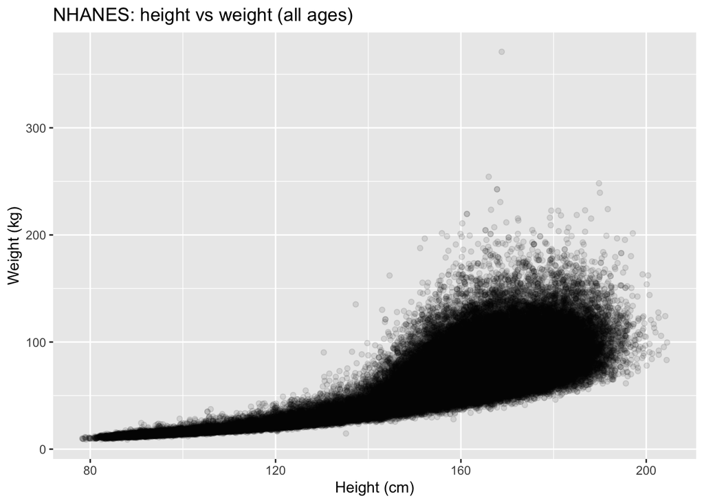

```r
ggplot(hw, aes(BMXHT, BMXWT)) +
  geom_point(alpha = 0.1) +
  labs(x = "Height (cm)", y = "Weight (kg)",
       title = "NHANES: height vs weight (all ages)")
```

```r
res_all <- cor.test(hw$BMXHT, hw$BMXWT)
res_all
```

```
##
##  Pearson's product-moment correlation
##
## data:  hw$BMXHT and hw$BMXWT
## t = 416.41, df = 109405, p-value < 2.2e-16
## alternative hypothesis: true correlation is not equal to 0
## 95 percent confidence interval:
##  0.7807271 0.7853119
## sample estimates:
##       cor
## 0.7830301
```

```r
# Restrict to adults by joining to demographics on SEQN
# Check the real DEMO table name first: grep("DEMO", tabs, value = TRUE)
hw_adults <- DBI::dbGetQuery(con, "
  SELECT b.BMXHT, b.BMXWT
  FROM NHANES_BMX b
  JOIN NHANES_DEMO d ON b.SEQN = d.SEQN
  WHERE d.RIDAGEYR >= 18
    AND b.BMXHT IS NOT NULL AND b.BMXWT IS NOT NULL")
nrow(hw_adults)
```

```
## [1] 70231
```

```r
res_adults <- cor.test(hw_adults$BMXHT, hw_adults$BMXWT)
res_adults
```

```
##
##  Pearson's product-moment correlation
##
## data:  hw_adults$BMXHT and hw_adults$BMXWT
## t = 125.11, df = 70229, p-value < 2.2e-16
## alternative hypothesis: true correlation is not equal to 0
## 95 percent confidence interval:
##  0.4208577 0.4329534
## sample estimates:
##       cor
## 0.4269246
```

**Results and interpretation:**

The correlation between height and weight was r = 0.78, with a p-value below 2.2e-16. Because the p-value is smaller than 0.05, I reject the null hypothesis. This means there is a positive correlation between height and weight: taller people tend to weigh more. When I only looked at adults, the correlation dropped to r = 0.43. This is probably because children get taller and heavier as they age, so including all ages makes the relationship look stronger.

# Question 2

## 2.1 Download the data and save it as a .csv

I used the RNAseq example from the Week 1 notes, GSE266550.

```r
# Load GEODataDownload from the course script (lines 651-733).
# Line 706 is changed to use the gene-name file I downloaded in my browser,
# because the NCBI link in the script returned a web page instead of the file.
script_lines <- readLines("~/Downloads/Week 1 Intro to fundamentals of R, obtaining open source data, and data management containers/2-Week1_Script.R")
script_lines[706] <- '    apath <- "~/Downloads/Human.GRCh38.p13.annot.tsv.gz"'
eval(parse(text = script_lines[651:733]))
```

```r
RNAseqData <- GEODataDownload(DS = "GSE266550",
                              gpl = "GPL18573",
                              gsm = "1011101100",
                              PlateAnnotInfo = "Only needed for MicroArrays",
                              GenerateMetaData = "Only needed for MicroArrays",
                              Technology = "RNAseq")
dim(RNAseqData)
```

```
## [1] 17867    17
```

```r
colnames(RNAseqData)
```

```
##  [1] "ENTREZID"       "SYMBOL"         "GENENAME"       "log2FoldChange"
##  [5] "pvalue"         "padj"           "GSM8250221"     "GSM8250222"
##  [9] "GSM8250223"     "GSM8250224"     "GSM8250225"     "GSM8250226"
## [13] "GSM8250227"     "GSM8250228"     "GSM8250229"     "GSM8250230"
## [17] "GSM8250231"
```

```r
write.csv(RNAseqData, "GSE266550_data.csv", row.names = FALSE)
reloaded <- read.csv("GSE266550_data.csv")
dim(RNAseqData)
```

```
## [1] 17867    17
```

```r
dim(reloaded)
```

```
## [1] 17867    17
```

```r
dim(RNAseqData) == dim(reloaded)
```

```
## [1] TRUE TRUE
```

**How the code works:**

write.csv() saves the RNAseqData object as a file on my computer. read.csv() then reads the file back into R as a new object called reloaded. The TRUE TRUE result shows that the number of rows and columns are the same, so no data was lost when saving.

## 2.2 Subset_Comparison column

```r
reloaded$Subset_Comparison <- "Treatment vs control"
head(reloaded$Subset_Comparison)
```

```
## [1] "Treatment vs control" "Treatment vs control" "Treatment vs control"
## [4] "Treatment vs control" "Treatment vs control" "Treatment vs control"
```

```r
dim(reloaded)
```

```
## [1] 17867    18
```

Adding a Subset_Comparison column is useful because if I later combine results from several different experiments into one table, the label tells me which data set each row came from. Without it, the same gene could show up more than once with different fold changes, and I wouldn’t know which comparison each number belongs to.

## 2.3 Average expression per sample

```r
sample_means <- colMeans(reloaded[, 7:17])
sample_means
```

```
## GSM8250221 GSM8250222 GSM8250223 GSM8250224 GSM8250225 GSM8250226 GSM8250227
##   634.8458   764.0078  1410.2532   281.5408   774.8239  1293.2043  1353.4401
## GSM8250228 GSM8250229 GSM8250230 GSM8250231
##   764.5271   700.1257   730.9305   680.7027
```

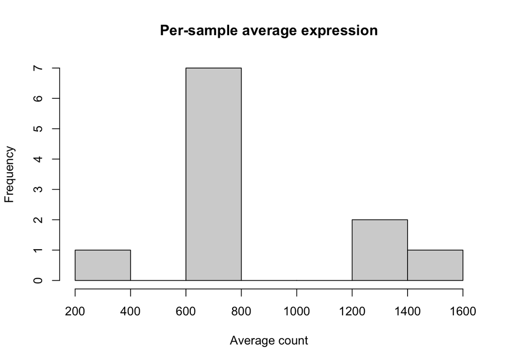

```r
hist(sample_means, main = "Per-sample average expression", xlab = "Average count")
```

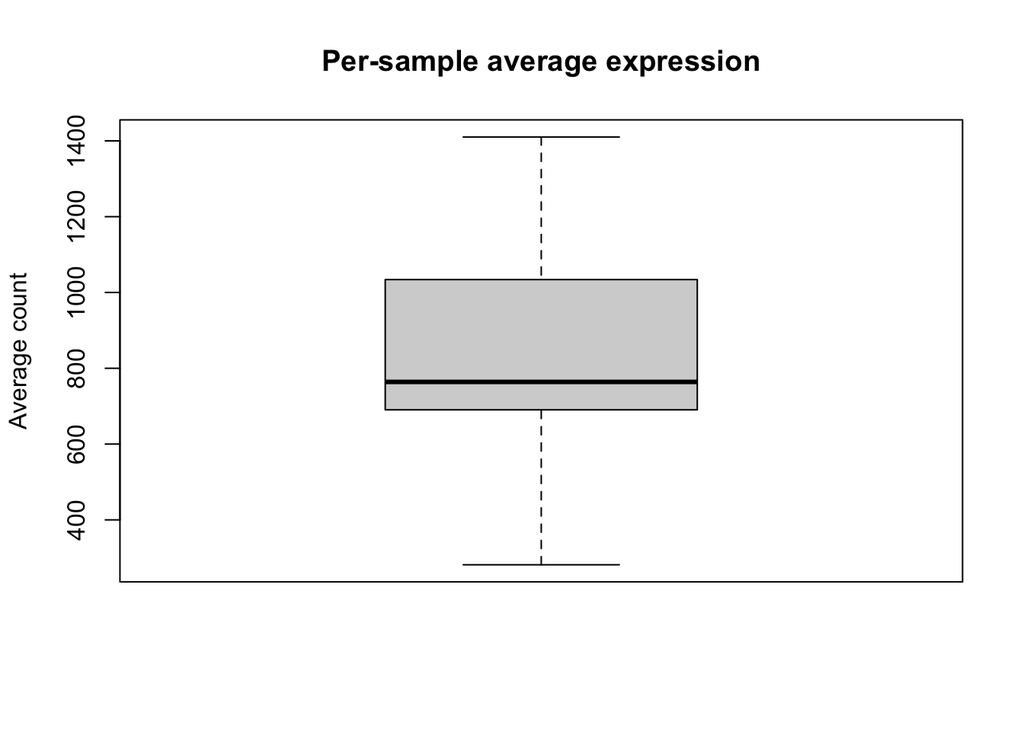

```r
boxplot(sample_means, main = "Per-sample average expression", ylab = "Average count")
```

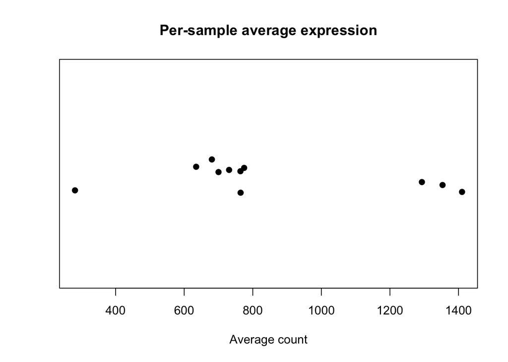

```r
stripchart(sample_means, method = "jitter", pch = 19,
           main = "Per-sample average expression", xlab = "Average count")
```

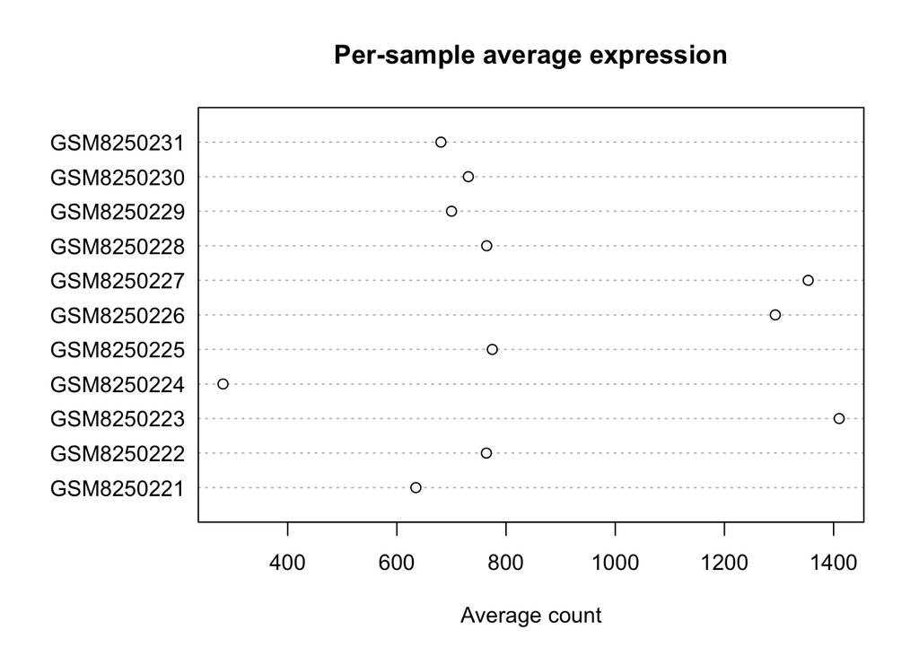

```r
dotchart(sample_means, main = "Per-sample average expression", xlab = "Average count")
```

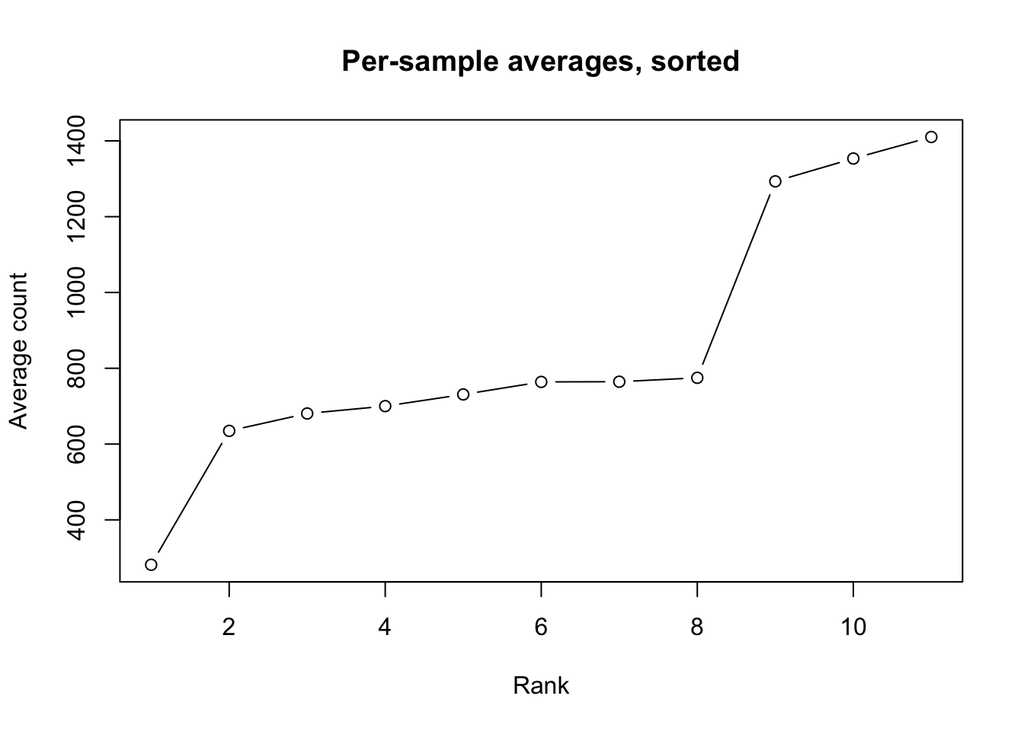

```r
plot(sort(sample_means), type = "b",
     main = "Per-sample averages, sorted", xlab = "Rank", ylab = "Average count")
```

## 2.4 Average expression per gene

```r
gene_means <- rowMeans(reloaded[, 7:17])
names(gene_means) <- reloaded$SYMBOL
length(gene_means)
```

```
## [1] 17867
```

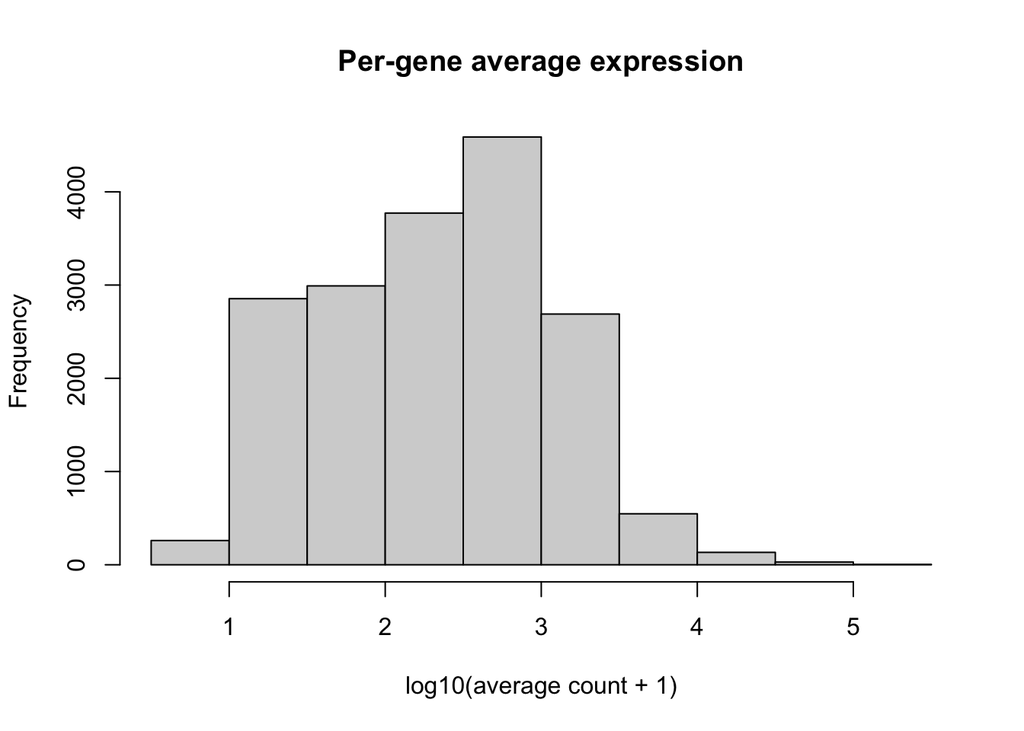

```r
hist(log10(gene_means + 1), main = "Per-gene average expression",
     xlab = "log10(average count + 1)")
```

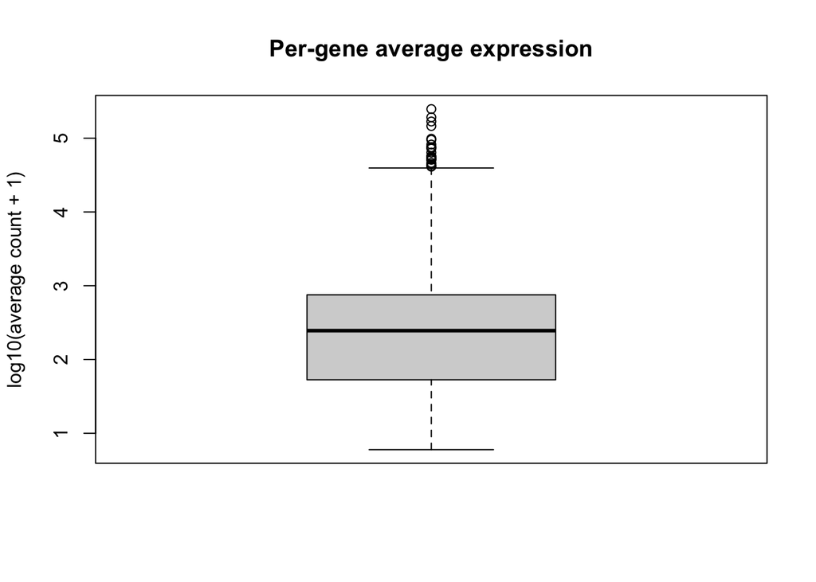

```r
boxplot(log10(gene_means + 1), main = "Per-gene average expression",
        ylab = "log10(average count + 1)")
```

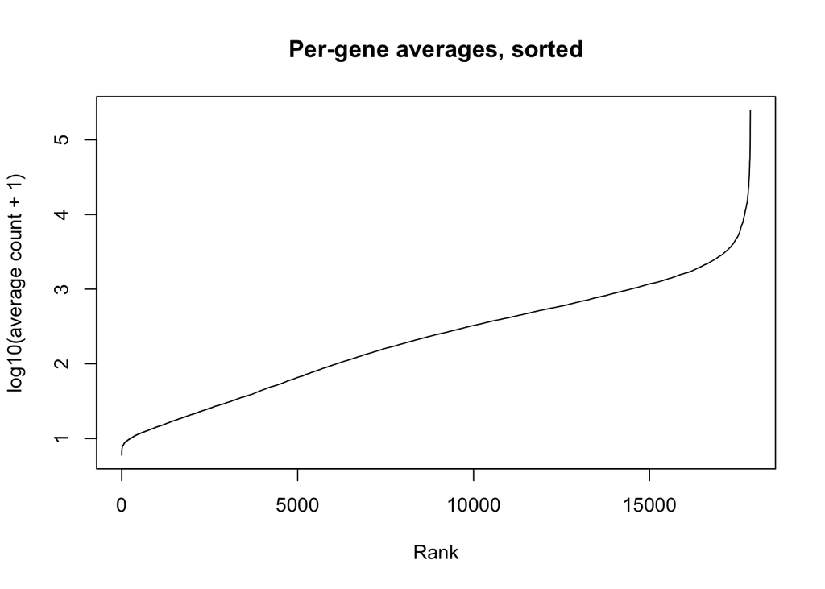

```r
plot(sort(log10(gene_means + 1)), type = "l",
     main = "Per-gene averages, sorted", xlab = "Rank", ylab = "log10(average count + 1)")
```

## 2.5 Top 5 and bottom 5 genes

```r
top5 <- sort(gene_means, decreasing = TRUE)[1:5]
top5
```

```
##      COX1    EEF1A1      RNR2       ND4       HBB
## 247977.91 191801.27 168265.36 146029.64  98254.45
```

```r
bottom5 <- sort(gene_means)[1:5]
bottom5
```

```
##       CHRNA2        KCNE5        SIRPD       LY6G6F LOC100131496
##     5.000000     5.545455     5.636364     5.909091     5.909091
```

[figure not shown]

```r
# Get the counts for these 10 genes across all 11 samples
ten_genes <- c(names(top5), names(bottom5))
ten_counts <- reloaded[match(ten_genes, reloaded$SYMBOL), 7:17]
rownames(ten_counts) <- ten_genes

boxplot(t(ten_counts), las = 2, log = "y",
        main = "Top 5 and bottom 5 genes across samples",
        ylab = "Count (log scale)")
```

**Interpretation:**

the top 5 genes are COX1, RNR2, ND4,these are mitochondrial genes, HBB is a hemoglobin beta, and EEF1A1 helps build proteins in cells.

the bottoms CHRNA2, KCNES, SIRPD, LY6G6F AND LOC100131496 these dont average much, so they were barely detected.

## 2.6 Volcano plot

```r
reloaded$Significant <- reloaded$padj < 0.05 & abs(reloaded$log2FoldChange) > 1
table(reloaded$Significant)
```

```
##
## FALSE  TRUE
## 17567    40
```

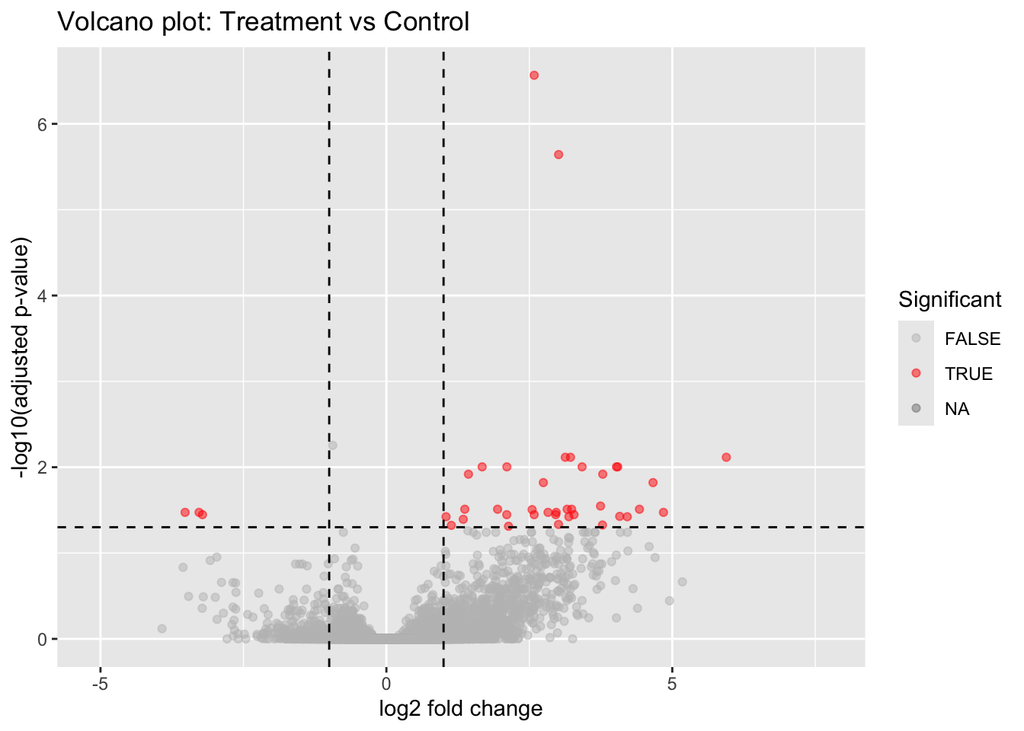

```r
ggplot(reloaded, aes(x = log2FoldChange, y = -log10(padj), color = Significant)) +
  geom_point(alpha = 0.5) +
  geom_hline(yintercept = -log10(0.05), linetype = "dashed") +
  geom_vline(xintercept = c(-1, 1), linetype = "dashed") +
  scale_color_manual(values = c("grey", "red")) +
  labs(title = "Volcano plot: Treatment vs Control",
       x = "log2 fold change", y = "-log10(adjusted p-value)")
```

## 2.7 MA plot

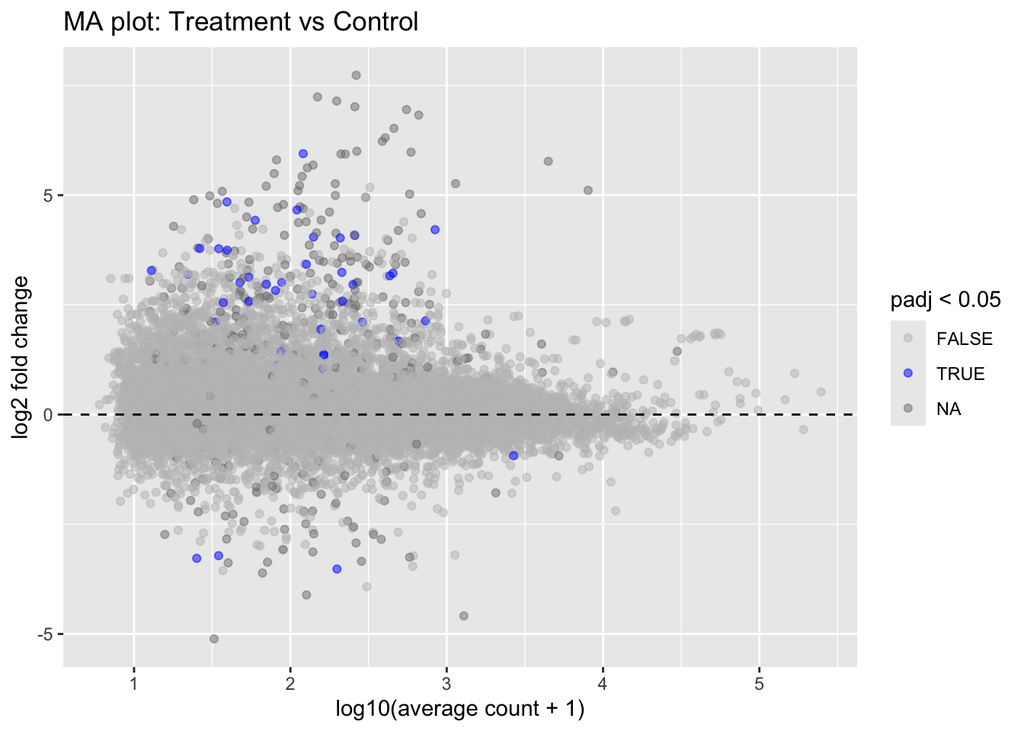

```r
reloaded$AvgExpr <- gene_means

ggplot(reloaded, aes(x = log10(AvgExpr + 1), y = log2FoldChange, color = padj < 0.05)) +
  geom_point(alpha = 0.5) +
  geom_hline(yintercept = 0, linetype = "dashed") +
  scale_color_manual(values = c("grey", "blue")) +
  labs(title = "MA plot: Treatment vs Control",
       x = "log10(average count + 1)", y = "log2 fold change", color = "padj < 0.05")
```

**How to read an MA plot and how it differs from a volcano plot:**

In an MA plot, the x-axis shows how strongly each gene is expressed (its average count), and the y-axis shows the log2 fold change, or how much the gene changed in treatment. The dashed line at 0 means no change, so genes above the line went up and genes below went down. Blue points are genes with an adjusted p-value below 0.05.

The difference from a volcano plot is that a volcano plot shows fold change against significance (the adjusted p-value), while an MA plot shows fold change against average expression. In my MA plot, the points are more spread out on the left side, because genes with low counts are noisier.

# Question 3

## 3.1 Build the SummarizedExperiment

I used the 10 samples that were in the DESeq2 analysis (columns 7 to 16). GSM8250231 was left out because the gsm code from the notes only has 10 digits, so that sample has no group.

```r
library(SummarizedExperiment)

counts <- as.matrix(reloaded[, 7:16])
rownames(counts) <- reloaded$ENTREZID
log_counts <- log2(counts + 1)

gene_info <- data.frame(SYMBOL = reloaded$SYMBOL,
                        log2FoldChange = reloaded$log2FoldChange,
                        padj = reloaded$padj,
                        row.names = reloaded$ENTREZID)

codes <- strsplit("1011101100", "")[[1]]
groups <- ifelse(codes == "1", "Treatment", "Control")
sample_info <- data.frame(Group = groups, row.names = colnames(counts))
sample_info
```

```
##                Group
## GSM8250221 Treatment
## GSM8250222   Control
## GSM8250223 Treatment
## GSM8250224 Treatment
## GSM8250225 Treatment
## GSM8250226   Control
## GSM8250227 Treatment
## GSM8250228 Treatment
## GSM8250229   Control
## GSM8250230   Control
```

## 3.2 Check that the names match

```r
all(rownames(counts) == rownames(gene_info))
```

```
## [1] TRUE
```

```r
all(colnames(counts) == rownames(sample_info))
```

```
## [1] TRUE
```

```r
se <- SummarizedExperiment(assays = list(counts = counts, log_counts = log_counts),
                           rowData = gene_info,
                           colData = sample_info)
se
```

```
## class: SummarizedExperiment
## dim: 17867 10
## metadata(0):
## assays(2): counts log_counts
## rownames(17867): 1 2 ... 115271120 115308161
## rowData names(3): SYMBOL log2FoldChange padj
## colnames(10): GSM8250221 GSM8250222 ... GSM8250229 GSM8250230
## colData names(1): Group
```

## 3.3 Subsetting

```r
se_treat <- se[, se$Group == "Treatment"]
dim(se_treat)
```

```
## [1] 17867     6
```

```r
se_sig <- se[which(rowData(se)$padj < 0.05), ]
dim(se_sig)
```

```
## [1] 41 10
```

```r
se_both <- se[which(rowData(se)$padj < 0.05), se$Group == "Treatment"]
dim(se_both)
```

```
## [1] 41  6
```

## 3.4 Top 5 DE genes

```r
top5_ids <- rownames(se)[order(rowData(se)$padj)][1:5]
top5_table <- assay(se, "counts")[top5_ids, ]
rownames(top5_table) <- rowData(se)[top5_ids, "SYMBOL"]
knitr::kable(top5_table, caption = "Raw counts for the top 5 DE genes")
```

Raw counts for the top 5 DE genes

|  | GSM8250221 | GSM8250222 | GSM8250223 | GSM8250224 | GSM8250225 | GSM8250226 | GSM8250227 | GSM8250228 | GSM8250229 | GSM8250230 |
| --- | --- | --- | --- | --- | --- | --- | --- | --- | --- | --- |
| BICDL1 | 261 | 41 | 560 | 128 | 318 | 62 | 305 | 440 | 94 | 45 |
| LINC01550 | 39 | 11 | 206 | 28 | 43 | 13 | 76 | 59 | 10 | 3 |
| RAB37 | 1461 | 2126 | 3409 | 490 | 1184 | 6597 | 2917 | 1921 | 3741 | 2985 |
| CD22 | 504 | 78 | 735 | 460 | 318 | 132 | 160 | 2171 | 108 | 79 |
| NDFIP2 | 54 | 4 | 200 | 10 | 32 | 25 | 41 | 194 | 10 | 5 |

## 3.5 Why use a SummarizedExperiment?

A SummarizedExperiment keeps the counts, the gene information, and the sample information linked in one object. When I subset it, for example to keep only treatment samples, all pieces are filtered at the same time, so the genes and samples always stay matched. With separate data frames, I would have to filter each one by myself, and if I made a mistake, the samples could get mixed up without any warning. It also let me store two assays (raw counts and log counts) for the same genes and samples.

When I would use it: I would choose a SummarizedExperiment when my data has a matrix of measurements (like genes × samples) plus information about both the rows and the columns, and when I want to use Bioconductor packages like DESeq2. For a simple table with one row per observation, like the NHANES height and weight data, a normal data frame is easier.

# Question 4

Bioconductor puts genes as rows and samples as columns because there are usually many more genes (about 17,000 here) than samples (only 10), and a tall table is easier to store and look at. It also lets gene information go in rowData and sample information go in colData.

Statistical learning functions like lm() expect the opposite: one row per sample (the thing we measured) and one column per feature (gene) (the variables we use to predict). If I gave lm() my expression matrix as it is, it would treat each gene as an observation and each sample as a variable. The results would be wrong, because I would be comparing genes instead of comparing samples. To fix it, I would first flip the matrix with t().

## 4.2 Correlation function

```r
gene_cor <- function(se, gene_id, variable, source = "colData") {
  # 1. Get this gene's expression across all samples
  expr <- assay(se, "log_counts")[gene_id, ]

  # 2. Get the metadata variable from colData or rowData
  if (source == "colData") {
    meta <- colData(se)[[variable]]
  } else {
    meta <- rowData(se)[gene_id, variable]
  }

  # 3. CHECK before doing anything
  if (length(expr) != length(meta)) {
    stop("Can't compare: the gene has ", length(expr), " values but '",
         variable, "' has ", length(meta), " value(s).")
  }
  if (!is.numeric(meta)) {
    stop("'", variable, "' is not numeric, so it can't be correlated.")
  }

  # 4. Only if the checks pass: run the test
  result <- cor.test(expr, meta)
  list(estimate = result$estimate, p.value = result$p.value)
}
```

**How the function works:**

The function first gets the gene’s expression values from the log_counts assay. Then it gets the metadata variable from either colData or rowData. Before running anything, it checks that both have the same length (number of values) and that the variable is numeric. If either check fails, stop() gives an error message. Only if the checks pass does it run cor.test() and return the estimate and p-value.

### Using a colData variable

```r
se$Group_num <- ifelse(se$Group == "Treatment", 1, 0)
my_gene <- top5_ids[1]
rowData(se)[my_gene, "SYMBOL"]
```

```
## [1] "BICDL1"
```

```r
gene_cor(se, my_gene, "Group_num", source = "colData")
```

```
## $estimate
##       cor
## 0.8925843
##
## $p.value
## [1] 0.0005106705
```

### Using a rowData variable

```r
gene_cor(se, my_gene, "log2FoldChange", source = "rowData")
```

```
## Error in `gene_cor()`:
## ! Can't compare: the gene has 10 values but 'log2FoldChange' has 1 value(s).
```

The function stopped with an error, because the gene has 10 expression values (one per sample) but log2FoldChange has only 1 value (one per gene). A per-gene value is the same for every sample, so it can’t be correlated with values that change across samples. This connects to 4.1: colData describes the samples (columns), and rowData describes the genes (rows). My length check caught this instead of returning a number that looks real but means nothing.

# Question 5 (optional)

# AI DISCLAIMER

I used Claude Code, it gave me code templates with blanks to fill in when I stuck too long on a question/code and it explained errors, explained concepts in simpler terms, and suggested corrections to my written answers. I ran all the code myself and wrote the interpretations with its feedback.